[figure not shown]

[figure not shown]

[figure not shown]

# Part 1: Maps

This section compares political contributions in Boston by ZIP code for two tender types: credit card and check. The contribution data are first aggregated by ZIP code and tender type, then joined to the Boston ZIP code map.

### Map of Boston Political Contributions

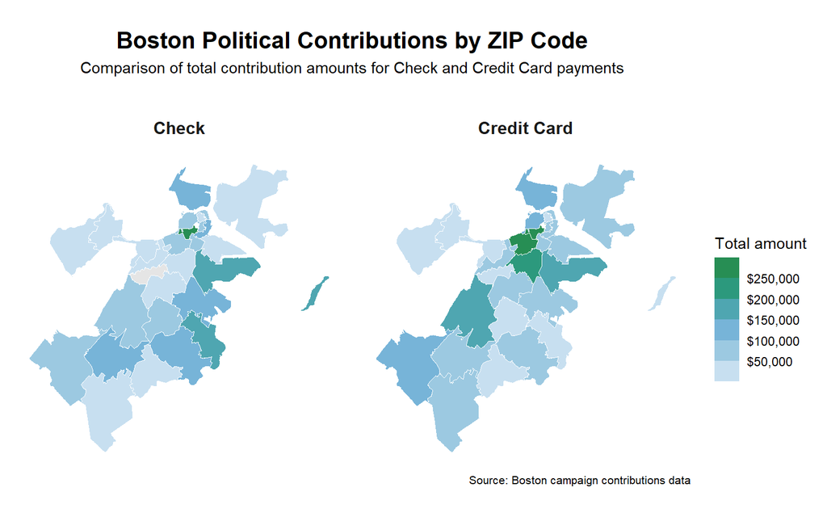

> **Note:** Darker ZIP codes represent higher total contribution amounts. Both Check and Credit Card contributions are concentrated in a relatively small number of Boston ZIP codes. Credit Card contributions appear more spatially concentrated in central areas of the city, while Check contributions show a slightly more dispersed distribution across ZIP codes.

# Part 2: Text

In this section, I create text visualizations based on word frequencies and bigrams from a text about immigration titled *“The administration has detained 400,000 immigrants: What do we know about their children?”*

### Word Cloud

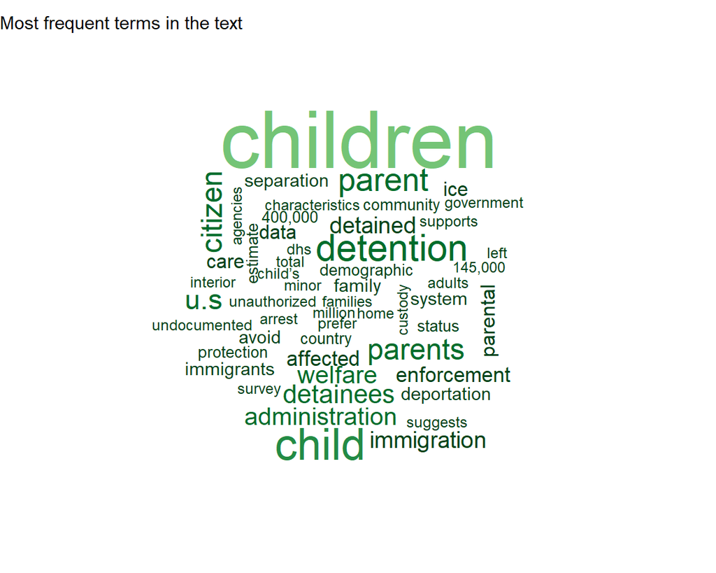

### Bigram Co-occurrence Network

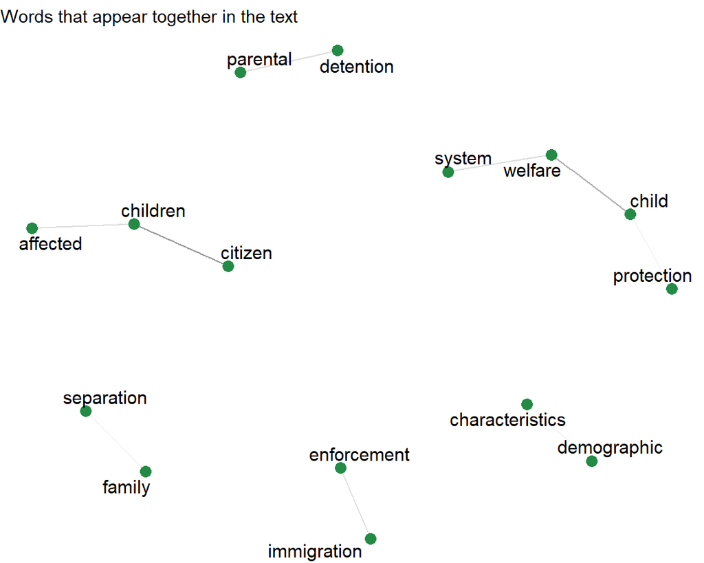